# cv9.R

Marek

2023-04-13

```r
library(latexpdf)
```

# Dvojrozmerny datovy subor, korelacna analyza

Analyzujeme dvojrozmerny datovy subor. Ratame charakteristiky pre jednorozmerne subory, pribudnu charakteristiky pre dvojrozmerny subor. Priklad. Tabulka uvadza cenu pevnych diskov (y) ich kapacitu (x) od vyrobcu ABC. Zratajte vektor strednych hodnot a disperzii.

```r
x <- c(160, 250, 320, 500, 750, 900, 1000, 1500, 2000)
y <- c(789, 800, 851, 874, 1193, 1200, 1335, 1704, 2073)
c(mean(x), mean(y))
```

```
## [1]  820.000 1202.111
```

```r
c(var(x), var(y))
```

```
## [1] 376425.0 198922.1
```

Dalej ratame charakteristiku dvojrozmerneho datoveho suboru kovarianciu (Personova, Kendallova, Spearmanova). Je to cislo, ktore nam charakterizuje, ci je medzi zlozkami linearna zavislost alebo nie, ci koreluju. Kym neznormujeme toto cislo, tak mozeme povedat iba jedine, cov = 0 zlozky su nekorelovanea ako cov != 0 su korelovane.

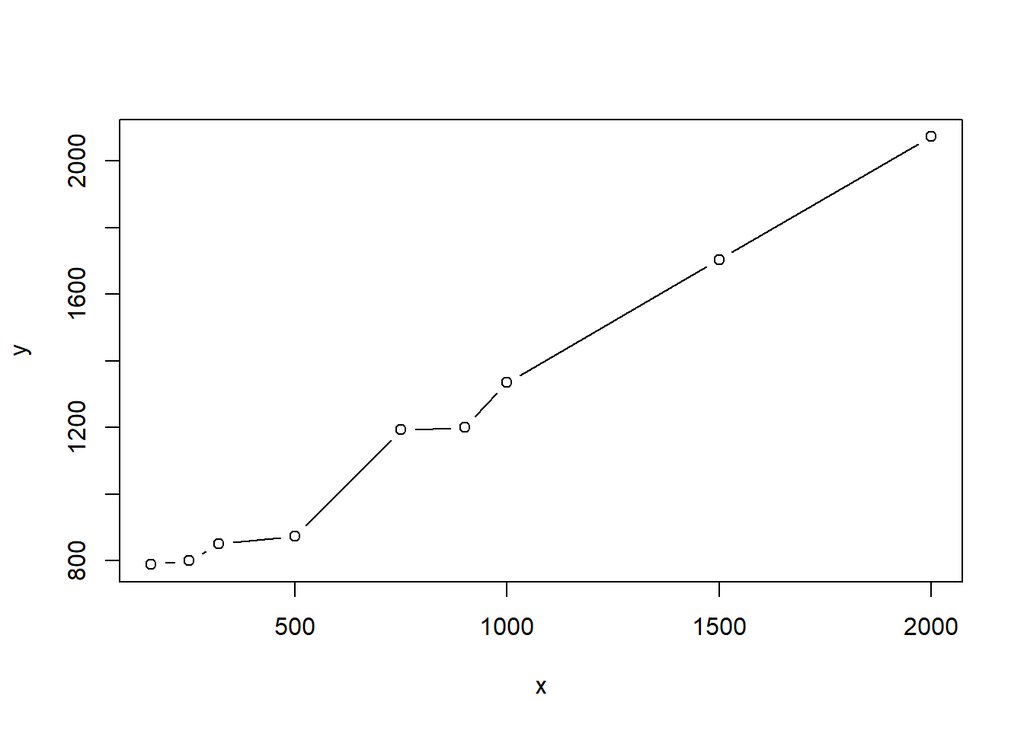

```r
plot(x, y, type = 'b')
```

```r
cov(x, y) #korelovane
```

```
## [1] 271966.2
```

```r
cov(x, y, method = 'kendall')
```

```
## [1] 72
```

```r
cov(x, y, method = 'spearman')
```

```
## [1] 7.5
```

Aby sme zistili, ako silno sa ovplyvnuju, je potrebne nromovat kovarianciu, dostaneme korelacny koeficient, co je cislo medzi -1 a 1. Blizke -1, 1 silna, silna korelacia, silna linearna zavislost. Blizke 0, nekorelovane a linearne nezavisle iba pre normalne rozdelene data. Zlozitejsie zavislosti sa nemusia odhalit. Pearsonov korelacny koeficient je citlivy na vybocujuce hodnoty, vsetky naraz ratat.Pripravime funkciu korelacie.

```r
cor(x, y)
```

```
## [1] 0.9938807
```

```r
korelacie <- function(x, y){c('Pearson' = cor(x, y),
                              'Kendall' = cor(x, y, method = 'kendall'),
                              'Spearman' = cor(x, y, method = 'spearman'))}
korelacie(x, y)
```

```
##   Pearson   Kendall  Spearman
## 0.9938807 1.0000000 1.0000000
```

Testovat korelacny koeficient mozeme, dvojrozmerne data ale musia byt normalne rozdelene, testujeme hypotezu o nulovosti korelacneho koeficientu.
$$H_0\quad \rho=0\quad H_1\quad
\rho \neq 0$$
kniznice pre test normality

```r
library(nortest)
library(mvnormtest)
```

uprava dat, dvojrozmerny subor

```r
data <- rbind(x, y)
mshapiro.test(data)
```

```
##
##  Shapiro-Wilk normality test
##
## data:  Z
## W = 0.86547, p-value = 0.1099
```

P hodnota > 0.05 nezamietam hypotezu o normalite dat mozeme testovat nulovost korelacneho koeficienta

```r
cor.test(x, y) #zamietam H0
```

```
##
##  Pearson's product-moment correlation
##
## data:  x and y
## t = 23.806, df = 7, p-value = 5.867e-08
## alternative hypothesis: true correlation is not equal to 0
## 95 percent confidence interval:
##  0.9700441 0.9987619
## sample estimates:
##       cor
## 0.9938807
```

```r
cor.test(x, y, method = 'kendall') #zamietam H0
```

```
##
##  Kendall's rank correlation tau
##
## data:  x and y
## T = 36, p-value = 5.511e-06
## alternative hypothesis: true tau is not equal to 0
## sample estimates:
## tau
##   1
```

```r
cor.test(x, y, method = 'spearman') #zamietam H0
```

```
##
##  Spearman's rank correlation rho
##
## data:  x and y
## S = 0, p-value = 5.511e-06
## alternative hypothesis: true rho is not equal to 0
## sample estimates:
## rho
##   1
```

graf s viac informaciami, nacitame kniznice

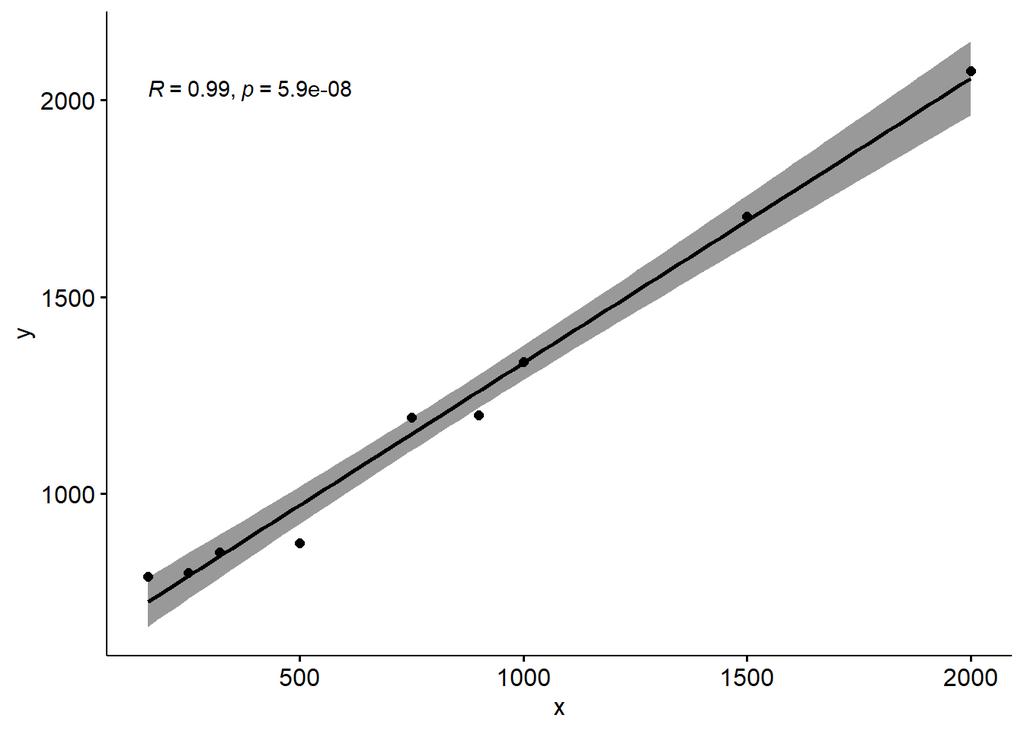

```r
library(ggplot2)
library(ggpubr)
data1 <- data.frame(x, y)
ggscatter(data1, 'x', 'y',
          add = 'reg.line',
          conf.int = T,
          cor.coef = T)
```

Nasiumulujeme linearne nezavisle, linearne zavisle a data so zlozitejsou zavislostou, grafy a korelacne koeficienty

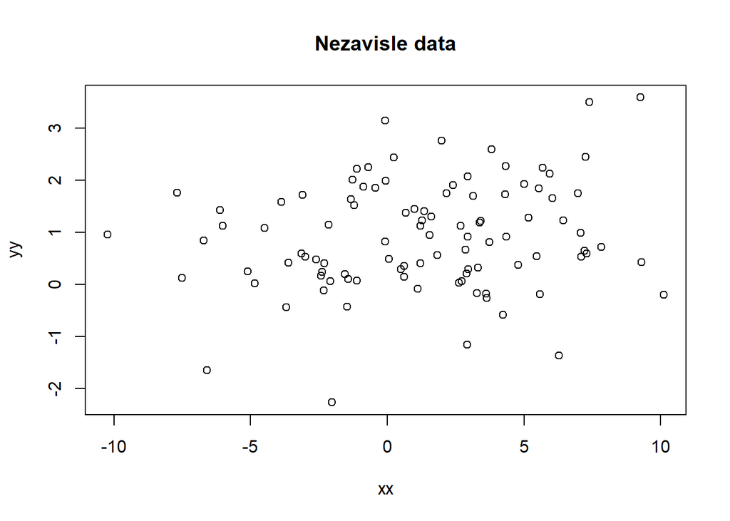

```r
xx <- rnorm(100, 2, 4)
yy <- rnorm(100, 1, 1)
plot(xx, yy, main = 'Nezavisle data')
```

```r
korelacie(xx, yy)
```

```
##   Pearson   Kendall  Spearman
## 0.1788016 0.1034343 0.1647165
```

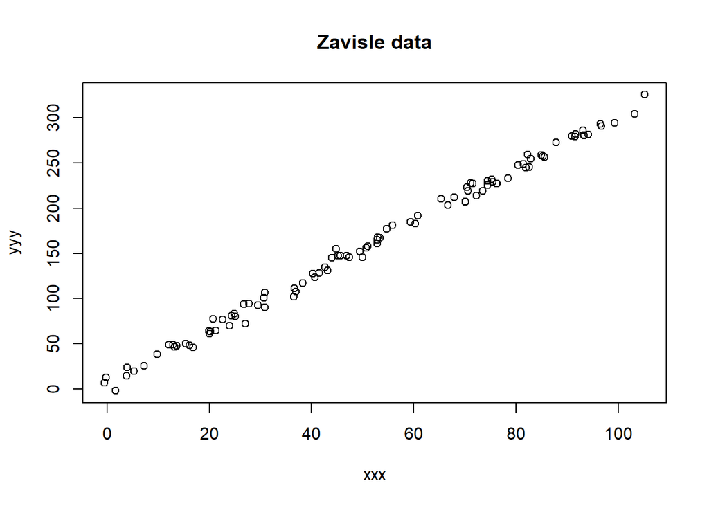

```r
xxx <- 1:100+xx
yyy <- 2+3*xxx+rnorm(100, 2, 6)
plot(xxx, yyy, main = 'Zavisle data')
```

```r
korelacie(xxx, yyy)
```

```
##   Pearson   Kendall  Spearman
## 0.9977918 0.9567677 0.9966637
```

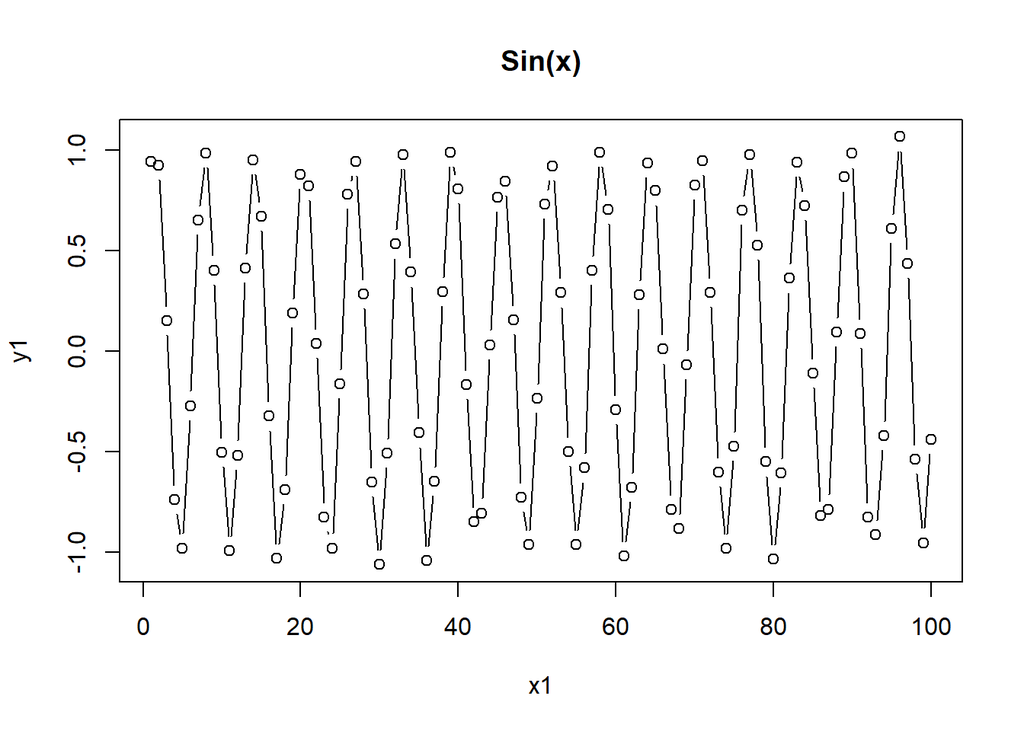

```r
x1 <- 1:100
y1 <- sin(x1) + rnorm(100, 0, 0.05)
plot(x1, y1, main='Sin(x)', type = 'b')
```

```r
korelacie(x1, y1)
```

```
##     Pearson     Kendall    Spearman
## -0.03782328 -0.02101010 -0.02945095
```